# R Programming Coursework

Naomi Danielle Torrisi

### Assessment 1 30%

# Question 1: Load the file Sales.tsv with the first column as the rownames (2%)

### Setting up

To prepare for this coursework, I downloaded the assessment.zip file, which automatically created a folder named Assessment containing all the required input files: “Counts.tsv”, “Genes.tsv”, “Sales.tsv”, “SampleData.tsv”. This folder is located in my downloads directory: /Users/naomi/Downloads/R Programming Coursework - Naomi Torrisi/ An additional folder named Output is currently empty and will store results generated by the analysis, such as tables and plots stored in the same directory as Assessment.

### Installing packages

In this section, I installed the tidyverse and ggpubr packages, which extend R’s functionality for data manipulation and visualisation. In R, many useful functions are not built into the base software but instead come from external packages developed by the R community. I installed these packages to enhance the analytical and plotting capabilities of my R environment for this coursework.

The tidyverse (short for ‘tidy data universe’) is a collection of packages such as dplyr, tibble, readr, and ggplot2 designed to make data manipulation, cleaning, and visualisation consistent, readable and efficient. The ggpubr package (short for ‘ggplot2 + pubr’ meaning ‘grammar of graphics, publication ready’) builds upon ggplot2 by providing functions for adding statistical results (eg. correlations, p-values, regression lines), customising themes and labels, and combining multiple plots into a single professional figure.

```r
## Install the tidyverse and ggpubr packages to extend base R functionality for data manipulation and visualisation (only needs to be done once per setup)
## tidyverse adds functions for clean, consistent data analysis; ggpubr adds functions for creating publication-ready plots.
install.packages("tidyverse")
install.packages("ggpubr")
install.packages("emmeans")
install.packages("multcompView")
```

### Loading files

In this section, I imported the Sales.tsv dataset into R using read.delim() function. Because .tsv files are tab-separated by default, the read.delim() function automatically recognises tab spacing between columns, so there was no need to manually specify a separator argument. Please run this chunk of code:

```r
## Load in the Sales dataset
Sales <- read.delim('/Users/naomi/Downloads/R Programming Coursework - Naomi Torrisi /Assessment/Sales.tsv')
Sales
```

| Year | Jan | Feb | Mar | Apr | May | Jun | Jul | Aug | Sep | Oct | Nov | Dec |
| --- | --- | --- | --- | --- | --- | --- | --- | --- | --- | --- | --- | --- |
| 2003 | 349 | 303 | 216 | 361 | 331 | 403 | 252 | 265 | 289 | 283 | 204 | 264 |
| 2004 | 320 | 297 | 335 | 319 | 326 | 482 | 461 | 408 | 428 | 282 | 499 | 410 |
| 2005 | 388 | 527 | 505 | 517 | 465 | 315 | 334 | 426 | 379 | 454 | 303 | 405 |
| 2006 | 480 | 499 | 412 | 434 | 426 | 405 | 445 | 387 | 493 | 434 | 369 | 328 |
| 2007 | 477 | 281 | 354 | 359 | 409 | 416 | 385 | 457 | 435 | 331 | 450 | 292 |
| 2008 | 435 | 452 | 423 | 493 | 478 | 445 | 475 | 446 | 408 | 490 | 455 | 401 |
| 2009 | 265 | 254 | 253 | 286 | 275 | 273 | 265 | 288 | 262 | 296 | 290 | 293 |
| 2010 | 596 | 206 | 793 | 346 | 425 | 723 | 427 | 756 | 378 | 411 | 118 | 441 |
| 2011 | 621 | 698 | 759 | 840 | 869 | 819 | 604 | 506 | 716 | 889 | 694 | 714 |
| 2012 | 700 | 500 | 482 | 513 | 667 | 713 | 472 | 745 | 681 | 633 | 508 | 520 |

[output cut: 10 more lines]

```r
## Note: read.delim() automatically recognises tab-separated values (.tsv) files
## So there is no need to manually specify the separator argument (sep = "\t").
## This function reads the file into a dataframe where each column represents a variable.
```

Once loaded, the resulting dataframe, named Sales, displayed the monthly sales values for each year, which can now be used for subsequent data manipulation and analyses.

### Column and Rownames

By default, when using the read.delim() function in R, every column in a .tsv file is treated as a regular variable. In the sales.tsv dataset, however, the first column represents identifiers (years) rather than variables to be analysed. Therefore, it’s more appropriate to use this column as the row names rather than as a data column.

To manage row names effectively, I used functions from the tibble package which is part of the tidyverse suite. This allowed me to move the “Year” column into the row name position using column_to_rownames(), ensuring that each row is now uniquely identified by its corresponding year.

This step is useful for subsequent analyses, such as calculating yearly averages or plotting trends over time, because this preserves numeric columns for analysis but removes the Year column from future summaries. Thus, it allows R to recognise each year as a distinct observation rather than as part of the data to be summarised.

```r
## Load tibble package (from tidyverse) to manage rownames
library(tibble)
## Convert the 'Year' column to rownames using the tibble package
## This moves the Year values into the row labels and removes the column from the dataframe, allowing each row to be uniquely identified by year for later analysis
Sales <- column_to_rownames(Sales, "Year")
## View dataframe to confirm that 'Year' is now used as rownames
Sales
```

|  | Jan | Feb | Mar | Apr | May | Jun | Jul | Aug | Sep | Oct | Nov | Dec |
| --- | --- | --- | --- | --- | --- | --- | --- | --- | --- | --- | --- | --- |
| 2003 | 349 | 303 | 216 | 361 | 331 | 403 | 252 | 265 | 289 | 283 | 204 | 264 |
| 2004 | 320 | 297 | 335 | 319 | 326 | 482 | 461 | 408 | 428 | 282 | 499 | 410 |
| 2005 | 388 | 527 | 505 | 517 | 465 | 315 | 334 | 426 | 379 | 454 | 303 | 405 |
| 2006 | 480 | 499 | 412 | 434 | 426 | 405 | 445 | 387 | 493 | 434 | 369 | 328 |
| 2007 | 477 | 281 | 354 | 359 | 409 | 416 | 385 | 457 | 435 | 331 | 450 | 292 |
| 2008 | 435 | 452 | 423 | 493 | 478 | 445 | 475 | 446 | 408 | 490 | 455 | 401 |
| 2009 | 265 | 254 | 253 | 286 | 275 | 273 | 265 | 288 | 262 | 296 | 290 | 293 |
| 2010 | 596 | 206 | 793 | 346 | 425 | 723 | 427 | 756 | 378 | 411 | 118 | 441 |
| 2011 | 621 | 698 | 759 | 840 | 869 | 819 | 604 | 506 | 716 | 889 | 694 | 714 |
| 2012 | 700 | 500 | 482 | 513 | 667 | 713 | 472 | 745 | 681 | 633 | 508 | 520 |

[output cut: 10 more lines]

This instructs R to use the ‘Year’ column name as the row labels instead. I did this to make the data easier to understand and work with as the IDs are now clearly assigned to each row.

# Question 2: Part 1 - Calculate the mean of each row (3%).

In this section, I calculated the average sales for each year by taking the mean across all twelve monthly columns using the rowMeans() function. This produced a single summary value for each year, representing the overall average sales across all months. These mean values were displayed directly rather than added to the main dataset, as it is good practice to keep derived statistics separate so that they can be easily recalculated if the underlying data changes.

```r
## Calculate the average sales for each year using rowMeans()
print("Average sales for each year:")
```

```
[1] "Average sales for each year:"
```

```r
row_means <- rowMeans(Sales)
row_means
```

```
                  2003                   2004                   2005                   2006                   2007                   2008                   2009                   2010                   2011                   2012
 293.33333333333331439  380.58333333333331439  418.16666666666668561  426.00000000000000000  387.16666666666668561  450.08333333333331439  275.00000000000000000  468.33333333333331439  727.41666666666662877  594.50000000000000000
                  2013                   2014                   2015                   2016                   2017                   2018                   2019                   2020                   2021                   2022
 526.00000000000000000  793.83333333333337123  780.41666666666662877  927.33333333333337123 1079.16666666666674246  734.50000000000000000 1287.16666666666674246 1690.83333333333325754 2038.58333333333325754 2094.83333333333348492
```

# Question 2: Part 2 - List the top 5 years with the highest mean sales.

I sorted the calculated yearly averages in descending order with sort(decreasing = TRUE) to identify which years had the highest overall sales. I then subsetted the sorted list by indices [1:5] to extract the top five years, providing a clear summary of the dataset’s five best-performing years in terms of mean sales.

```r
## Sort rows in descending order of mean sales for each year
## rowMeans() calculates the average across all 12 monthly columns
## Sort (decreasing = TRUE) orders the results from highest to lowest
print("Highest to Lowest Average Yearly Sales:")
```

```
[1] "Highest to Lowest Average Yearly Sales:"
```

```r
sorted_means <- Sales %>% rowMeans() %>% sort(decreasing = TRUE)
sorted_means
```

```
                  2022                   2021                   2020                   2019                   2017                   2016                   2014                   2015                   2018                   2011
2094.83333333333348492 2038.58333333333325754 1690.83333333333325754 1287.16666666666674246 1079.16666666666674246  927.33333333333337123  793.83333333333337123  780.41666666666662877  734.50000000000000000  727.41666666666662877
                  2012                   2013                   2010                   2008                   2006                   2005                   2007                   2004                   2003                   2009
 594.50000000000000000  526.00000000000000000  468.33333333333331439  450.08333333333331439  426.00000000000000000  418.16666666666668561  387.16666666666668561  380.58333333333331439  293.33333333333331439  275.00000000000000000
```

```r
## List top 5 years with the highest mean sales
## names() extracts only the year labels, and [1:5] subsets the first five indices
print("Top Five Best Performing Years:")
```

```
[1] "Top Five Best Performing Years:"
```

```r
Top5Years <- names(sorted_means[1:5])
Top5Years
```

```
[1] "2022" "2021" "2020" "2019" "2017"
```

```r
## Note: Averages are kept separate from the dataset to preserve the integrity of the raw data.
```

### Results Interpretation

# Question 3: Part 1 - Calculate the median of each column (5%).

In this section, I calculated the median sales value for each month across all years using the apply() function. The argument 2 tells R to apply the function across columns rather than rows, and median() returns the middle value for each monthly column. I did not store the median values directly inside the main dataset, as it’s best practice to keep summary statistics separate. This ensures that if the data is later updated or corrected, all summary values can be easily recalculculated without altering the original dataset.

```r
## Calculate median sales for each month (across all years)
## Use the argument (2) which tells R to apply the function to columns only
## median() returns the middle value of each column
print("Median sales for each month across all years:")
```

```
[1] "Median sales for each month across all years:"
```

```r
col_medians <- apply(Sales, 2, median)
col_medians
```

```
  Jan   Feb   Mar   Apr   May   Jun   Jul   Aug   Sep   Oct   Nov   Dec
634.0 627.5 707.5 515.0 634.0 655.5 539.5 590.0 650.0 601.5 620.0 610.5
```

```r
## Note: Do not store summary statistics directly in the data table
## Keeping calculated values separate allows easy recalculation if the data changes
```

### Results Interpretation

Monthly sales medians ranged from around 515 in April to about 707 in March. March had the strongest sales overall, while April showed the weakest performance. This pattern suggests that sales tend to be higher at the start of the year and drop slightly in spring before levelling out through the rest of the year.

# Question 3: Part 2 - List the top 5 months with the highest median sales.

In this section, I identified the five months with the highest median sales values. I first sorted the column medians (calculated using apply(Sales, 2, median)) in descending order using sort() function with the argument decreasing = TRUE. This arranged monthly medians from highest to lowest. I then used subsetting [1:5] along with names() function to extract the names of the top five months, providing a quick summary of which months had the strongest sale performance.

```r
## Sort the monthly median sales values in descending order (highest to lowest)
sorted_medians <- sort(col_medians, decreasing = TRUE)
sorted_medians
```

```
  Mar   Jun   Sep   Jan   May   Feb   Nov   Dec   Oct   Aug   Jul   Apr
707.5 655.5 650.0 634.0 634.0 627.5 620.0 610.5 601.5 590.0 539.5 515.0
```

```r
## Select the top 5 months
## names() extracts the month names
## [1:5] subsets the first five indices
Top5Months <- names(sorted_medians[1:5])
Top5Months
```

```
[1] "Mar" "Jun" "Sep" "Jan" "May"
```

### Results Interpretation

The five months with the highest median sales were March, June, September, January, and May. This shows that sales tended to peak during early spring and mid-year, with another smaller rise after the new year. These patterns suggest possible seasonal trends, where certain times of year consistently perform better than others.

# Question 4: Part 1 - Generate a scatter plot of the sales for the 2 months with the highest median values (5%). Add a linear regression line and correlation statistics to this plot.

The scatterplot was generated using ggplot2 for visualisation and ggpubr for adding statistical annotations.

These packages allowed the inclusion of linear regression line to visualise the strength of relationship between the two months with the highest median sales, as well as the automatic calculation and display of the Pearson correlation coefficient (r) and p-value to quantify the strength and significance of the relationship between both variables.

The p-value was less than 0.05, indicating that the observed relationship is statistically significant.

```r
## Select top 2 months from highest median sales values
## names() extracts the column names and [1:2] subsets the first two (highest) entries
Top2Months <- names(sorted_medians[1:2])
Top2Months
```

```
[1] "Mar" "Jun"
```

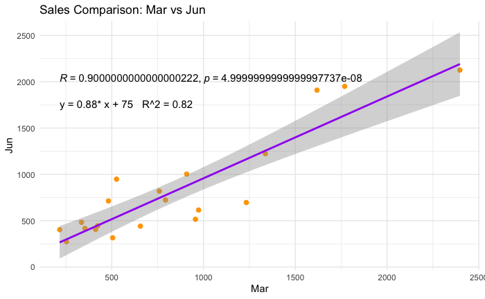

```r
## Load required packages for plotting
library(ggplot2) ## Used to create plots
library(ggpubr) ## Provides functions for adding correlation, regression and annotations

## Create a scatter plot comparing sales between the two highest-median months
ggplot(Sales, aes(x = .data[[Top2Months[1]]], y = .data[[Top2Months[2]]])) +

  ## Plot orange points to show individual yearly sales values
         geom_point(colour = "orange", size = 2) +

  ## Add a purple linear regression line to show the trend between the two months
         geom_smooth(method = "lm", se = TRUE, colour = "purple") +

  ## Display Pearson correlation coefficient (r) and p-value on the plot
         stat_cor(method = "pearson", colour = "black", label.x.npc = "left", label.y.npc = "top", size = 4) +

  ## Display the regression equation and R^2 value as text
         stat_regline_equation(
  aes(label = paste(..eq.label.., ..rr.label.., sep = "   ")), ## Include equation and R^2
  label.x.npc = "left", label.y.npc = "top", vjust = 5,
  size = 4, output.type = "text"  ## Shows the equation and R^2 value as normal text instead of turning them into a math formula
) +

  ## Add the axis labels and plot title automatically using the month names
  labs(
    x = Top2Months[1],
    y = Top2Months[2],
   title = paste("Sales Comparison:", Top2Months[1], "vs", Top2Months[2])
) +
  ## Apply a minimalistic theme for better readability
         theme_minimal()
```

### Results Interpretation

The scatter plot shows a clear positive trend between sales in March and June; when sales were high in March, they were also high in June. The linear regression line confirms this strong relationship (R = 0.90, p < 0.001), meaning the two months follow a very similar sales pattern. This suggests that the same seasonal or market factors likely influenced performance in both months.

# Question 5: Convert the rownames into a column and turn the data into long format so that the data can be processed using ggplot2 (5%)

In this section, I changed the Sales data from a wide to a long format so that it could be used with ggplot2. In the original dataset, each year was a single row and the sales for each month were spread across separate columns. To fix this, I used rownames_to_column() from the tibble package to turn the row names (years) into a proper column called “Year”. I then used pivot_longer() from tidyr to gather all the monthly columns into two columns; “Month” for the month names and “Sales” for their values. This created one row per year-month combination, which is the structure that ggplot2 needs for plotting grouped data.

```r
## Load required packages (tibble and tidyr are part of tidyverse) to use rownames_to_column() and pivot_longer() functions
library(tibble)
library(tidyr)

## Convert the Sales data from wide format to long format for use with ggplot2
Sales_long <- Sales %>%
        rownames_to_column("Year") %>% ## Move rownames into a new column called 'Year'
        pivot_longer(cols = -Year, ## Transform all other columns (months) except 'Year'
                     names_to = "Month", ## Create a new column 'Month' containing former column names
                     values_to = "Sales") ## Create a new column 'Sales' containing the corresponding values
## View the resulting long-format dataframe
Sales_long
```

| Year | Month | Sales |
| --- | --- | --- |
| 2003 | Jan | 349 |
| 2003 | Feb | 303 |
| 2003 | Mar | 216 |
| 2003 | Apr | 361 |
| 2003 | May | 331 |
| 2003 | Jun | 403 |
| 2003 | Jul | 252 |
| 2003 | Aug | 265 |
| 2003 | Sep | 289 |
| 2003 | Oct | 283 |

[output cut: 230 more lines]

# Question 6: Part 1 - Using the long form dataframe, generate a Boxplot of the sales values for the 2 years with the highest mean sales (10%)

# Part 2: Determine whether to use a parametric or non-parametric test for these data.

# Part 3: Include the correct statistics on the plot.

### Identifying and Filtering Years

In this section, I first loaded the required packages for data manipulation, excluding those that were already loaded in earlier chunks (such as ggplot2 and ggpubr) as these only need to be loaded once per run. In this case, I loaded the dplyr package to use its key functions like filter(), group_by(), and summarise().

I then identified the two years with the highest mean sales from the object sorted_means, using which I had previously created by calculating the average sales for each year and sorting the results in descending order. This allowed me to isolate the best-performing years for further analysis. Using [1:2] slices the first two elements from the vector sorted_means and extracts the named numeric vector (the corresponding years “2021” and “2022”) for further filtering and plotting.

Next, I used the filter() function from the dplyr package to extract only those two years from the long-format dataset Sales_long. I used the pipe operator (%>%) which passes the result of one function directly into the next and the “is in” operator (%in%) which tests whether each year is included in the Top2Years vector. Combined, these make the filtering process concise and readable, improving the overall efficiency of the data manipulation workflow. Only those rows were retained, leaving monthly sales data for the two top-performing years.

Finally, I converted the Year column into a factor variable with levels matching Top2Years, ensuring that when visualised in ggplot2, the years appear on the x-axis in the correct ranked order (rather than alphabetically). This preserves the logical structure of the anaysis and makes the final boxplot easier to interpret:

```r
## Load packages at the start
library(dplyr)  ## for data manipulation (filter, group_by, summarise)

## NOTE: I do not need to reload ggplot2 or ggppub2 as these are previously loaded in question 4. Make sure to run question 4 code block before running this code block.

## Identify the top two years from the already-sorted means (long format already created in Question 5)
print("Two Best-Performing Sales Years:")
```

```
[1] "Two Best-Performing Sales Years:"
```

```r
Top2Years <- names(sorted_means[1:2])
Top2Years
```

```
[1] "2022" "2021"
```

```r
## Filter the long-format data for these top two years
Sales_top2 <- Sales_long %>%
  filter(Year %in% Top2Years)

## Ensure Year is a factor so it appears neatly on x-axis
Sales_top2$Year <- factor(Sales_top2$Year, levels = Top2Years)
```

### Assessing Normality and Parametric Decision

In this section, I assessed whether the monthly sales for the two top-performing years followed a normal distribution so I could select the appropriate statistical test. To do this, I used the group_by() and summarise() functions from the dplyr package to apply the Shapiro-Wilk test separately to each year’s sales values.

I chose the Shapiro-Wilk test as it is reliable for small datasets (ie 12 monthly values per year). Both 2021 (p=0.74) and 2022 (p=0.13) returned p-values greater than 0.05, meaning neither distrubtion significantly deviated from normality:

```r
## Assess the normality of montly sales for each of the top 2 years using a Shapiro-Wilk test
Sales_top2 %>%
  group_by(Year) %>%   ## group the data by Year so each year is tested separately
  summarise(p_value = shapiro.test(Sales)$p.value) ## perform the Shapiro–Wilk test on Sales within each group ## and extract the resulting p-value for normality assessment
```

| Year | p_value |
| --- | --- |
| 2022 | 0.13160207004952456655 |
| 2021 | 0.73988091562763214082 |

```r
## Both years have p > 0.05 (Shapiro–Wilk), confirming normality. Proceed with a parametric Welch's t-test.
```

Since the data met the assumption of normality, I used a parametric Welch’s two-sample t-test to compare the mean monthly sales between the two years. I chose the Welch test because, unlike the standard t-test, it doesn’t assume that both groups have equal variance. This makes it a safer and more reliable choice when the variability between the two years might not be exactly the same.

```r
## Conduct Welch's t-test
test_result <- t.test(Sales ~ Year, data = Sales_top2)
test_result
```

```
    Welch Two Sample t-test

data:  Sales by Year
t = 0.503254916711168288, df = 21.9939747357262618, p-value = 0.61978799415513253
alternative hypothesis: true difference in means between group 2022 and group 2021 is not equal to 0
95 percent confidence interval:
 -175.55541136392071166  288.05541136392122326
sample estimates:
   mean in group 2022    mean in group 2021
2094.8333333333334849 2038.5833333333332575
```

I then extracted key summary statistics from the test output including; t-value (t_val), degrees of freedom (df_val), p-value (p_val) and 95% confidence interval (ci_high and ci_low), rounded to two decimal places for readability:

```r
## Extract key test statistics for reporting
t_val <- round(test_result$statistic, 2) ## extract the t-value from the t-test output and round to 2 decimal places
df_val <- round(test_result$parameter, 1) ## extract the degrees of freedom (df) and round to 1 decimal place
p_val <- signif(test_result$p.value, 3) ## extract the p-value and round to 3 significant figures
ci_low <- round(test_result$conf.int[1], 2) ## extract the lower bound of the 95% confidence interval and round to 2 decimals
ci_high <- round(test_result$conf.int[2], 2) ## extract the upper bound of the 95% confidence interval and round to 2 decimals
```

These summary statistics where then combined into a single string (subtitle_txt) so that they could be displayed directly under the figure title, in a self-contained block that could be easily interpretable:

```r
## Prepare a text string for subtitle with full stats
subtitle_txt <- paste0(      ## combine all extracted values into a single formatted text string
  "Welch's t-test: t(", df_val, ") = ", t_val,   ## display the test type, t-value, and degrees of freedom
  ", p = ", p_val,    ## include the p-value
  "; 95% CI [", ci_low, ", ", ci_high, "]"   ## include the 95% confidence interval limits
)
```

Finally, I defined y_max to find the highest sales value, which then allowed me to position the p-value label neatly just above the tallest box on the plot:

```r
## Define the maximum sales value to calculate where the p-value label should go
y_max <- max(Sales_top2$Sales, na.rm = TRUE)
```

### Plot the boxplot with the correct statistics included

In this section, I created a boxplot to compare the distribution of monthly sales between the two top-performing years and to visually display the results of the statistical analysis. I used ggplot() function from the ggplot2 package to build the plot step-by-step, specifying that the x-axis represents the years, y axis represents the monthly sales values, and the boxes should be filled according to each year.

The geom_boxplot() function was then used to display the distribution of sales for each year, showing the median quartiles, and any potential outliers. I customised its appearance for clarity, setting width=0.6 to control the box width, alpha=0.6 to make the fill slightly transparent, and defining the outlier appearance with outlier.shape=1 and outlier.size=2.

To make the plot more informative, I added geom_jitter() to show the individual monthly data points as small black dots. These points were slightly spread horizontally (width=0.1) so they didn’t overlap, and made slightly transparent(alpha=0.7) for to see the overlapping points more clearly.

I then used stat_compare_means() from the ggpubr package to automatically include the p-value from the Welch’s t-test above the boxes. The function was set with method=“t.test” to match the test I used earlier, and label=“p.format” to display the p-value in an easy-to-read format such as “p=0.62”. The label position was adjusted using label.x=1.5 to centre it between the boxes and label.y = y_max * 1.05 to place it slightly above the tallest boxplot, based on the maximum sales value. I also expanded the y-axis range slightly (expand_limits(y = y_max * 1.10)) to ensure the p-value label didn’t overlap with the boxes.

Finally, I added informative axis labels and a title using labs() function with a subtitle that displays the key t-test statistics (t-value, degrees of freedom, p-value, and the 95% confidence interval) all combined earlier to give the variable subtitle_txt.

The theme_minimal function was applied last to give the figure a clean, professional layout by removing uneccessary background lines and clutter.

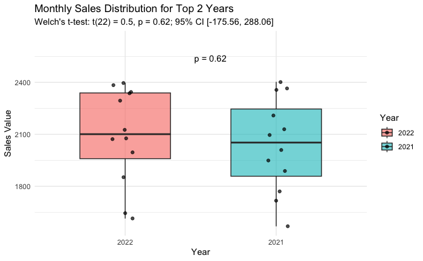

```r
## Generate boxplots showing the sales distribution for each year
ggplot(Sales_top2, aes(x = Year, y = Sales, fill = Year)) + ## map Year to x-axis, Sales to y-axis and colour by Year
  geom_boxplot(
    width = 0.6, ## adjust width of each box (default = 0.75)
    alpha = 0.6, ## adjust transparency of fill colour (1 is solid, 0 is transparent)
    outlier.shape = 1, ## define how outliers are drawn (16 = solid circle)
    outlier.size = 2) + ## make outliers slightly larger for visibility (default = 1.5)
## Note: No statistical outliers were detected within either year,
## so no outlier points are visible on the boxplots.

## Overlay each month’s actual sales value as a jittered point
  geom_jitter(
    width = 0.1, ## shifts jitter horizontally by 0.1 units so points don't overlap
    alpha = 0.7, ## makes points slightly transparent for readability
    colour = "black" ## sets point colour to black to contrast with box colours
  ) +

## Put the p-value at the midpoint between the two boxes (x = 1.5),
## and slightly above the tallest point. Also add headroom on the y-axis.
    stat_compare_means(
    method   = "t.test",   ## perform a Welch’s two-sample t-test between the two years
    label    = "p.format",  ## display the p-value in formatted form (e.g., "p = 0.042")
    label.x  = 1.5,         ## position the label horizontally at the midpoint between the two boxes
    label.y  = y_max * 1.05   ## place the label slightly above the tallest boxplot
  ) +
  expand_limits(y = y_max * 1.10) +  ## expand the y-axis range by 10% to ensure the p-value label is visible and not clipped

## Add axis labels and an informative title
  labs(title = "Monthly Sales Distribution for Top 2 Years", ## gives the plot an informative title
       subtitle = subtitle_txt,  ## displays Welch’s t-test stats underneath the title
       x = "Year", ## labels the x-axis
       y = "Sales Value" ## labels the y-axis
  ) +

## Apply a clean theme suitable for publication
  theme_minimal() ## will remove background gridlines and clutter to better focus on the data
```

### Results Interpretation

The boxplot shows that average monthly sales were slightly higher in 2022 compared with 2021, but the overlap in distributions is considerable. The Welch’s t-test (p = 0.62 rounded to 2 decimal places) suggests that this difference is not statistically significant, meaning sales performance remained broadly consistent between the two years.